# Credit Portfolio Risk Monitoring & Automation Dashboard

### PLOT 2.7: (bar plot)

“DPD Bucket by accounts (04. 61-90 DPD) ~ Total NOA vs Island”

```r
# Dataset: Gross, Net, and External
sqllab_gross_clean
```

```
#> # A tibble: 135,420 × 11
#>    cut_off_date island region area  branch bucket   noa outstanding_amount  date
#>    <date>       <fct>  <fct>  <fct> <fct>  <fct>  <int>              <dbl> <int>
#>  1 2025-11-01   Sumat… Aceh   Aceh… Aceh … 01. C…    53          91784130.     1
#>  2 2025-11-01   Sumat… Aceh   Aceh… Aceh … 02. 1…   185         254273192.     1
#>  3 2025-11-01   Sumat… Aceh   Aceh… Aceh … 03. 3…   173         431221028.     1
#>  4 2025-11-01   Sumat… Aceh   Aceh… Aceh … 04. 6…   271        1326525315.     1
#>  5 2025-11-01   Sumat… Aceh   Aceh… Aceh … 05. 9…   119         557134482.     1
#>  6 2025-11-01   Sumat… Aceh   Aceh… Aceh … 01. C…   176         836408397.     1
#>  7 2025-11-01   Sumat… Aceh   Aceh… Aceh … 02. 1…   443         850066868.     1
#>  8 2025-11-01   Sumat… Aceh   Aceh… Aceh … 03. 3…   369        1051253334.     1
#>  9 2025-11-01   Sumat… Aceh   Aceh… Aceh … 04. 6…   386         920064468.     1
#> 10 2025-11-01   Sumat… Aceh   Aceh… Aceh … 05. 9…   148         702017007.     1
#> # ℹ 135,410 more rows
#> # ℹ 2 more variables: month <dbl>, year <dbl>
```

```r
sqllab_net_clean
```

```
#> # A tibble: 135,420 × 11
#>    cut_off_date island region area  branch bucket   noa outstanding_amount  date
#>    <date>       <fct>  <fct>  <fct> <fct>  <fct>  <int>              <dbl> <int>
#>  1 2025-11-01   Sumat… Aceh   Aceh… Aceh … 01. C…    53          76934000.     1
#>  2 2025-11-01   Sumat… Aceh   Aceh… Aceh … 02. 1…   185         218410473.     1
#>  3 2025-11-01   Sumat… Aceh   Aceh… Aceh … 03. 3…   173         317760703.     1
#>  4 2025-11-01   Sumat… Aceh   Aceh… Aceh … 04. 6…   271         811554170.     1
#>  5 2025-11-01   Sumat… Aceh   Aceh… Aceh … 05. 9…   119         271330064.     1
#>  6 2025-11-01   Sumat… Aceh   Aceh… Aceh … 01. C…   176         581834603.     1
#>  7 2025-11-01   Sumat… Aceh   Aceh… Aceh … 02. 1…   443         748995851.     1
#>  8 2025-11-01   Sumat… Aceh   Aceh… Aceh … 03. 3…   369         877552083.     1
#>  9 2025-11-01   Sumat… Aceh   Aceh… Aceh … 04. 6…   386         558000043.     1
#> 10 2025-11-01   Sumat… Aceh   Aceh… Aceh … 05. 9…   148         335235117.     1
#> # ℹ 135,410 more rows
#> # ℹ 2 more variables: month <dbl>, year <dbl>
```

```r
sqllab_external_clean
```

```
#> # A tibble: 135,420 × 11
#>    cut_off_date island region area  branch bucket   noa outstanding_amount  date
#>    <date>       <fct>  <fct>  <fct> <fct>  <fct>  <int>              <dbl> <int>
#>  1 2025-11-01   Sumat… Aceh   Aceh… Aceh … 01. C…    53          64398309.     1
#>  2 2025-11-01   Sumat… Aceh   Aceh… Aceh … 02. 1…   185         206470008.     1
#>  3 2025-11-01   Sumat… Aceh   Aceh… Aceh … 03. 3…   173         231682208.     1
#>  4 2025-11-01   Sumat… Aceh   Aceh… Aceh … 04. 6…   271         648403168.     1
#>  5 2025-11-01   Sumat… Aceh   Aceh… Aceh … 05. 9…   119          50133476.     1
#>  6 2025-11-01   Sumat… Aceh   Aceh… Aceh … 01. C…   176         458579814.     1
#>  7 2025-11-01   Sumat… Aceh   Aceh… Aceh … 02. 1…   443         553795359.     1
#>  8 2025-11-01   Sumat… Aceh   Aceh… Aceh … 03. 3…   369         827679983.     1
#>  9 2025-11-01   Sumat… Aceh   Aceh… Aceh … 04. 6…   386         511141034.     1
#> 10 2025-11-01   Sumat… Aceh   Aceh… Aceh … 05. 9…   148          47998959.     1
#> # ℹ 135,410 more rows
#> # ℹ 2 more variables: month <dbl>, year <dbl>
```

Now, we’re going to derive the latest *NOA* (Number of accounts) from the *gross, net, and external dataset*, specifically for the *“04. 61-90 DPD”* bucket in each island.

```r
# Gross: NOA for "04. 61-90 DPD" bucket
DPD_bucket_by_accounts04_gross <- sqllab_gross_clean %>%
  filter(bucket == "04. 61-90 DPD",
         cut_off_date == "2025-11-01") %>%
  group_by(island) %>%
  summarise(total_noa = sum(noa)) %>%
  ungroup()

DPD_bucket_by_accounts04_gross
```

```
#> # A tibble: 7 × 2
#>   island               total_noa
#>   <fct>                    <int>
#> 1 Bali & Nusa Tenggara     11143
#> 2 Jawa                     21333
#> 3 Kalimantan               16461
#> 4 Maluku                    5442
#> 5 Papua                    16822
#> 6 Sulawesi                 20376
#> 7 Sumatera                 34614
```

```r
# Net: NOA for "04. 61-90 DPD" bucket
DPD_bucket_by_accounts04_net <- sqllab_net_clean %>%
  filter(bucket == "04. 61-90 DPD",
         cut_off_date == "2025-11-01") %>%
  group_by(island) %>%
  summarise(total_noa = sum(noa))%>%
  ungroup()

DPD_bucket_by_accounts04_net
```

```
#> # A tibble: 7 × 2
#>   island               total_noa
#>   <fct>                    <int>
#> 1 Bali & Nusa Tenggara     11143
#> 2 Jawa                     21333
#> 3 Kalimantan               16461
#> 4 Maluku                    5442
#> 5 Papua                    16822
#> 6 Sulawesi                 20376
#> 7 Sumatera                 34614
```

```r
# External: NOA for "04. 61-90 DPD" bucket
DPD_bucket_by_accounts04_external <- sqllab_external_clean %>%
  filter(bucket == "04. 61-90 DPD",
         cut_off_date == "2025-11-01") %>%
  group_by(island) %>%
  summarise(total_noa = sum(noa)) %>%
  ungroup()

DPD_bucket_by_accounts04_external
```

```
#> # A tibble: 7 × 2
#>   island               total_noa
#>   <fct>                    <int>
#> 1 Bali & Nusa Tenggara     11143
#> 2 Jawa                     21333
#> 3 Kalimantan               16461
#> 4 Maluku                    5442
#> 5 Papua                    16822
#> 6 Sulawesi                 20376
#> 7 Sumatera                 34614
```

We then *merge* and *pivot* all the latest *Gross, Net, and External NOA* into one dataset for easier visualization.

```r
# Merging Gross, Net, and External "04. 61-90 DPD" bucket NOA into one dataset
DPD_bucket_by_accounts04 <- DPD_bucket_by_accounts04_gross %>%
  inner_join(DPD_bucket_by_accounts04_net, by = "island") %>%
  inner_join(DPD_bucket_by_accounts04_external, by = "island") %>%
  rename(
    Gross = total_noa.x,
    Net = total_noa.y,
    External = total_noa
  )

DPD_bucket_by_accounts04
```

```
#> # A tibble: 7 × 4
#>   island               Gross   Net External
#>   <fct>                <int> <int>    <int>
#> 1 Bali & Nusa Tenggara 11143 11143    11143
#> 2 Jawa                 21333 21333    21333
#> 3 Kalimantan           16461 16461    16461
#> 4 Maluku                5442  5442     5442
#> 5 Papua                16822 16822    16822
#> 6 Sulawesi             20376 20376    20376
#> 7 Sumatera             34614 34614    34614
```

```r
# Pivot and adding NPL type column
DPD_bucket_by_accounts04 <- DPD_bucket_by_accounts04 %>%
  pivot_longer(
    cols = c(Gross, Net, External),
    names_to = "Type",
    values_to = "Total_accounts"
  ) %>%
  mutate(Type = factor(Type, levels = c("Gross", "Net", "External")))

DPD_bucket_by_accounts04
```

```
#> # A tibble: 21 × 3
#>    island               Type     Total_accounts
#>    <fct>                <fct>             <int>
#>  1 Bali & Nusa Tenggara Gross             11143
#>  2 Bali & Nusa Tenggara Net               11143
#>  3 Bali & Nusa Tenggara External          11143
#>  4 Jawa                 Gross             21333
#>  5 Jawa                 Net               21333
#>  6 Jawa                 External          21333
#>  7 Kalimantan           Gross             16461
#>  8 Kalimantan           Net               16461
#>  9 Kalimantan           External          16461
#> 10 Maluku               Gross              5442
#> # ℹ 11 more rows
```

```r
# tooltip
DPD_bucket_by_accounts04 <- DPD_bucket_by_accounts04 %>%
  mutate(
    label = glue(
      "Total accounts: {number(Total_accounts, big.mark = '.', decimal.mark = ',', accuracy = 1)}"
    )
  )

DPD_bucket_by_accounts04
```

```
#> # A tibble: 21 × 4
#>    island               Type     Total_accounts label
#>    <fct>                <fct>             <int> <glue>
#>  1 Bali & Nusa Tenggara Gross             11143 Total accounts: 11.143
#>  2 Bali & Nusa Tenggara Net               11143 Total accounts: 11.143
#>  3 Bali & Nusa Tenggara External          11143 Total accounts: 11.143
#>  4 Jawa                 Gross             21333 Total accounts: 21.333
#>  5 Jawa                 Net               21333 Total accounts: 21.333
#>  6 Jawa                 External          21333 Total accounts: 21.333
#>  7 Kalimantan           Gross             16461 Total accounts: 16.461
#>  8 Kalimantan           Net               16461 Total accounts: 16.461
#>  9 Kalimantan           External          16461 Total accounts: 16.461
#> 10 Maluku               Gross              5442 Total accounts: 5.442
#> # ℹ 11 more rows
```

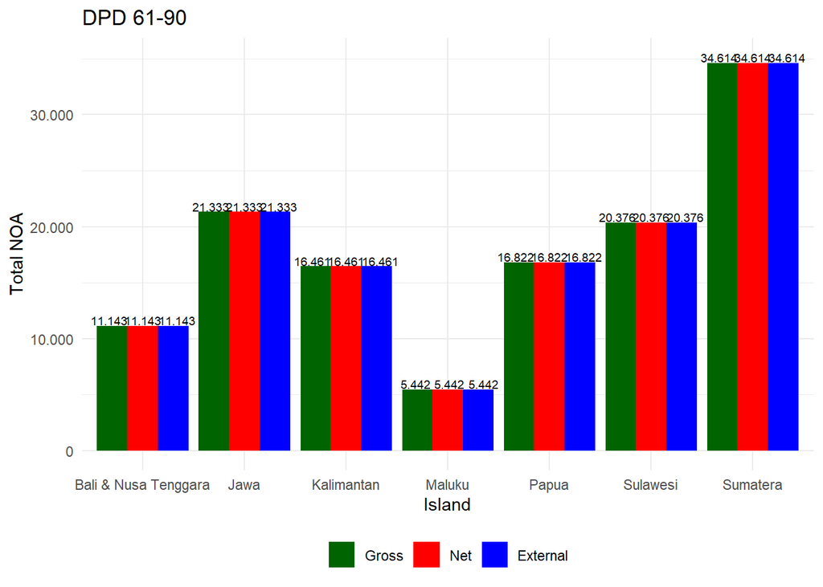

```r
# PLOT 2.7: DPD Bucket by accounts (04. 61-90 DPD)
plot2.7<- ggplot(DPD_bucket_by_accounts04, aes(x = island,
                    y = Total_accounts,
                    text = label)) +

  geom_col(position = position_dodge(width = 0.9),
           aes(fill = Type)) +
  geom_text(aes(y = Total_accounts + 500,
                label = format(Total_accounts,
                               big.mark = ".",
                               decimal.mark = ","),
                group = Type),
            position = position_dodge(width = 1),
            size = 2.5) +
   scale_y_continuous(labels = label_comma(big.mark = ".", decimal.mark = ",")) +
   scale_fill_manual(values = c("darkgreen", "red","blue"),
                    name = NULL) +
  labs(title = "DPD 61-90",
       x = "Island",
       y = "Total NOA") +
  theme_minimal() +
  theme(legend.position = "bottom")

plot2.7
```

```r
# This is for interactive plot
# ggplotly(plot2.7, tooltip = "text") %>%
#   layout(title = list(text = paste0(
#       "DPD 61-90")),
#       legend = list(orientation = "h",
#                     y = -0.3))
```

The chart displays **Total NOA** for **DPD 61–90** across several **islands** in Indonesia, grouped into **Gross**, **Net**, and **External** categories.

- **Sumatera** has the **highest** total at **34.614** accounts,
- while **Maluku** has the **lowest** at **5.442** accounts.

### PLOT 2.8: (bar plot)

“DPD Bucket by accounts (05. 90+ DPD) ~ Total NOA vs Island”

```r
# Dataset: Gross, Net, and External
sqllab_gross_clean
```

```
#> # A tibble: 135,420 × 11
#>    cut_off_date island region area  branch bucket   noa outstanding_amount  date
#>    <date>       <fct>  <fct>  <fct> <fct>  <fct>  <int>              <dbl> <int>
#>  1 2025-11-01   Sumat… Aceh   Aceh… Aceh … 01. C…    53          91784130.     1
#>  2 2025-11-01   Sumat… Aceh   Aceh… Aceh … 02. 1…   185         254273192.     1
#>  3 2025-11-01   Sumat… Aceh   Aceh… Aceh … 03. 3…   173         431221028.     1
#>  4 2025-11-01   Sumat… Aceh   Aceh… Aceh … 04. 6…   271        1326525315.     1
#>  5 2025-11-01   Sumat… Aceh   Aceh… Aceh … 05. 9…   119         557134482.     1
#>  6 2025-11-01   Sumat… Aceh   Aceh… Aceh … 01. C…   176         836408397.     1
#>  7 2025-11-01   Sumat… Aceh   Aceh… Aceh … 02. 1…   443         850066868.     1
#>  8 2025-11-01   Sumat… Aceh   Aceh… Aceh … 03. 3…   369        1051253334.     1
#>  9 2025-11-01   Sumat… Aceh   Aceh… Aceh … 04. 6…   386         920064468.     1
#> 10 2025-11-01   Sumat… Aceh   Aceh… Aceh … 05. 9…   148         702017007.     1
#> # ℹ 135,410 more rows
#> # ℹ 2 more variables: month <dbl>, year <dbl>
```

```r
sqllab_net_clean
```

```
#> # A tibble: 135,420 × 11
#>    cut_off_date island region area  branch bucket   noa outstanding_amount  date
#>    <date>       <fct>  <fct>  <fct> <fct>  <fct>  <int>              <dbl> <int>
#>  1 2025-11-01   Sumat… Aceh   Aceh… Aceh … 01. C…    53          76934000.     1
#>  2 2025-11-01   Sumat… Aceh   Aceh… Aceh … 02. 1…   185         218410473.     1
#>  3 2025-11-01   Sumat… Aceh   Aceh… Aceh … 03. 3…   173         317760703.     1
#>  4 2025-11-01   Sumat… Aceh   Aceh… Aceh … 04. 6…   271         811554170.     1
#>  5 2025-11-01   Sumat… Aceh   Aceh… Aceh … 05. 9…   119         271330064.     1
#>  6 2025-11-01   Sumat… Aceh   Aceh… Aceh … 01. C…   176         581834603.     1
#>  7 2025-11-01   Sumat… Aceh   Aceh… Aceh … 02. 1…   443         748995851.     1
#>  8 2025-11-01   Sumat… Aceh   Aceh… Aceh … 03. 3…   369         877552083.     1
#>  9 2025-11-01   Sumat… Aceh   Aceh… Aceh … 04. 6…   386         558000043.     1
#> 10 2025-11-01   Sumat… Aceh   Aceh… Aceh … 05. 9…   148         335235117.     1
#> # ℹ 135,410 more rows
#> # ℹ 2 more variables: month <dbl>, year <dbl>
```

```r
sqllab_external_clean
```

```
#> # A tibble: 135,420 × 11
#>    cut_off_date island region area  branch bucket   noa outstanding_amount  date
#>    <date>       <fct>  <fct>  <fct> <fct>  <fct>  <int>              <dbl> <int>
#>  1 2025-11-01   Sumat… Aceh   Aceh… Aceh … 01. C…    53          64398309.     1
#>  2 2025-11-01   Sumat… Aceh   Aceh… Aceh … 02. 1…   185         206470008.     1
#>  3 2025-11-01   Sumat… Aceh   Aceh… Aceh … 03. 3…   173         231682208.     1
#>  4 2025-11-01   Sumat… Aceh   Aceh… Aceh … 04. 6…   271         648403168.     1
#>  5 2025-11-01   Sumat… Aceh   Aceh… Aceh … 05. 9…   119          50133476.     1
#>  6 2025-11-01   Sumat… Aceh   Aceh… Aceh … 01. C…   176         458579814.     1
#>  7 2025-11-01   Sumat… Aceh   Aceh… Aceh … 02. 1…   443         553795359.     1
#>  8 2025-11-01   Sumat… Aceh   Aceh… Aceh … 03. 3…   369         827679983.     1
#>  9 2025-11-01   Sumat… Aceh   Aceh… Aceh … 04. 6…   386         511141034.     1
#> 10 2025-11-01   Sumat… Aceh   Aceh… Aceh … 05. 9…   148          47998959.     1
#> # ℹ 135,410 more rows
#> # ℹ 2 more variables: month <dbl>, year <dbl>
```

Now, we’re going to derive the latest *NOA* (Number of accounts) from the *gross, net, and external dataset*, specifically for the last bucket, *“05. 90+ DPD”* in each island.

```r
# Gross: NOA for "05. 90+ DPD" bucket
DPD_bucket_by_accounts05_gross <- sqllab_gross_clean %>%
  filter(bucket == "05. 90+ DPD",
         cut_off_date == "2025-11-01") %>%
  group_by(island) %>%
  summarise(total_noa = sum(noa)) %>%
  ungroup()

DPD_bucket_by_accounts05_gross
```

```
#> # A tibble: 7 × 2
#>   island               total_noa
#>   <fct>                    <int>
#> 1 Bali & Nusa Tenggara     10295
#> 2 Jawa                     21683
#> 3 Kalimantan               15088
#> 4 Maluku                    7162
#> 5 Papua                    17969
#> 6 Sulawesi                 19032
#> 7 Sumatera                 33241
```

```r
# Net: NOA for "05. 90+ DPD" bucket
DPD_bucket_by_accounts05_net <- sqllab_net_clean %>%
  filter(bucket == "05. 90+ DPD",
         cut_off_date == "2025-11-01") %>%
  group_by(island) %>%
  summarise(total_noa = sum(noa))%>%
  ungroup()

DPD_bucket_by_accounts05_net
```

```
#> # A tibble: 7 × 2
#>   island               total_noa
#>   <fct>                    <int>
#> 1 Bali & Nusa Tenggara     10295
#> 2 Jawa                     21683
#> 3 Kalimantan               15088
#> 4 Maluku                    7162
#> 5 Papua                    17969
#> 6 Sulawesi                 19032
#> 7 Sumatera                 33241
```

```r
# External: NOA for "05. 90+ DPD" bucket
DPD_bucket_by_accounts05_external <- sqllab_external_clean %>%
  filter(bucket == "05. 90+ DPD",
         cut_off_date == "2025-11-01") %>%
  group_by(island) %>%
  summarise(total_noa = sum(noa)) %>%
  ungroup()

DPD_bucket_by_accounts05_external
```

```
#> # A tibble: 7 × 2
#>   island               total_noa
#>   <fct>                    <int>
#> 1 Bali & Nusa Tenggara     10295
#> 2 Jawa                     21683
#> 3 Kalimantan               15088
#> 4 Maluku                    7162
#> 5 Papua                    17969
#> 6 Sulawesi                 19032
#> 7 Sumatera                 33241
```

We then *merge* and *pivot* all the latest *Gross, Net, and External NOA* into one dataset for easier visualization.

```r
# Merging Gross, Net, and External "05. 90+ DPD" bucket NOA into one dataset
DPD_bucket_by_accounts05 <- DPD_bucket_by_accounts05_gross %>%
  inner_join(DPD_bucket_by_accounts05_net, by = "island") %>%
  inner_join(DPD_bucket_by_accounts05_external, by = "island") %>%
  rename(
    Gross = total_noa.x,
    Net = total_noa.y,
    External = total_noa
  )

DPD_bucket_by_accounts05
```

```
#> # A tibble: 7 × 4
#>   island               Gross   Net External
#>   <fct>                <int> <int>    <int>
#> 1 Bali & Nusa Tenggara 10295 10295    10295
#> 2 Jawa                 21683 21683    21683
#> 3 Kalimantan           15088 15088    15088
#> 4 Maluku                7162  7162     7162
#> 5 Papua                17969 17969    17969
#> 6 Sulawesi             19032 19032    19032
#> 7 Sumatera             33241 33241    33241
```

```r
# Pivot and adding NPL type column
DPD_bucket_by_accounts05 <- DPD_bucket_by_accounts05 %>%
  pivot_longer(
    cols = c(Gross, Net, External),
    names_to = "Type",
    values_to = "Total_accounts"
  ) %>%
  mutate(Type = factor(Type, levels = c("Gross", "Net", "External")))

DPD_bucket_by_accounts05
```

```
#> # A tibble: 21 × 3
#>    island               Type     Total_accounts
#>    <fct>                <fct>             <int>
#>  1 Bali & Nusa Tenggara Gross             10295
#>  2 Bali & Nusa Tenggara Net               10295
#>  3 Bali & Nusa Tenggara External          10295
#>  4 Jawa                 Gross             21683
#>  5 Jawa                 Net               21683
#>  6 Jawa                 External          21683
#>  7 Kalimantan           Gross             15088
#>  8 Kalimantan           Net               15088
#>  9 Kalimantan           External          15088
#> 10 Maluku               Gross              7162
#> # ℹ 11 more rows
```

```r
# tooltip
DPD_bucket_by_accounts05 <- DPD_bucket_by_accounts05 %>%
  mutate(
    label = glue(
      "Total accounts: {number(Total_accounts, big.mark = '.', decimal.mark = ',', accuracy = 1)}"
    )
  )

DPD_bucket_by_accounts05
```

```
#> # A tibble: 21 × 4
#>    island               Type     Total_accounts label
#>    <fct>                <fct>             <int> <glue>
#>  1 Bali & Nusa Tenggara Gross             10295 Total accounts: 10.295
#>  2 Bali & Nusa Tenggara Net               10295 Total accounts: 10.295
#>  3 Bali & Nusa Tenggara External          10295 Total accounts: 10.295
#>  4 Jawa                 Gross             21683 Total accounts: 21.683
#>  5 Jawa                 Net               21683 Total accounts: 21.683
#>  6 Jawa                 External          21683 Total accounts: 21.683
#>  7 Kalimantan           Gross             15088 Total accounts: 15.088
#>  8 Kalimantan           Net               15088 Total accounts: 15.088
#>  9 Kalimantan           External          15088 Total accounts: 15.088
#> 10 Maluku               Gross              7162 Total accounts: 7.162
#> # ℹ 11 more rows
```

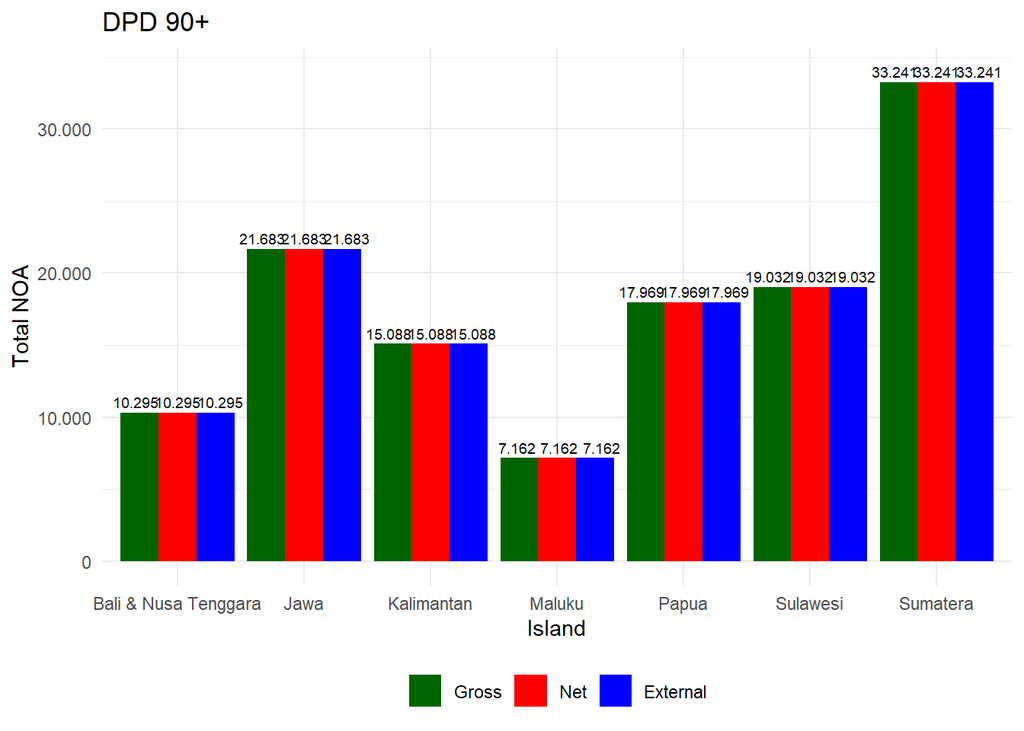

```r
# PLOT 2.8: DPD Bucket by accounts (05. 90+ DPD)
plot2.8 <- ggplot(DPD_bucket_by_accounts05, aes(x = island,
                    y = Total_accounts,
                    text = label)) +

  geom_col(position = position_dodge(width = 0.9),
           aes(fill = Type)) +
  geom_text(aes(y = Total_accounts + 750,
                label = format(Total_accounts,
                               big.mark = ".",
                               decimal.mark = ","),
                group = Type),
            position = position_dodge(width = 1),
            size = 2.5) +
   scale_y_continuous(labels = label_comma(big.mark = ".", decimal.mark = ",")) +
   scale_fill_manual(values = c("darkgreen", "red","blue"),
                    name = NULL) +
  labs(title = "DPD 90+",
       x = "Island",
       y = "Total NOA") +
  theme_minimal() +
  theme(legend.position = "bottom")

plot2.8
```

```r
# This is for interactive plot
# ggplotly(plot2.8, tooltip = "text") %>%
#   layout(title = list(text = paste0(
#       "DPD 90+")),
#       legend = list(orientation = "h",
#                     y = -0.3))
```

The chart shows **Total NOA** for **DPD 90+** across different **islands** in Indonesia, categorized into **Gross**, **Net**, and **External** values.

- **Sumatera** has the **highest** total at **33.241** accounts,
- while **Maluku** has the **lowest** at **7.162** accounts.

# TAB 3 (NPL DETAIL)

## Line 3.1 (NPL Net Detail: Island, Regional, Area, Branch)

In this section, we’re going to create a tab that *displays the outstanding amount, NOA, and NPL for each DPD bucket*, based on the selected *cut off date, island, region, area, and branch* in the dashboard.

### Island

For the *island level*, we’re going to create *two datasets*: the first will display the outstanding amount, NOA, and NPL for each DPD bucket across *all islands*, while the second will include a *specific cut-off date* for more detailed analysis.

```r
# Dataset: Net
sqllab_net_clean
```

```
#> # A tibble: 135,420 × 11
#>    cut_off_date island region area  branch bucket   noa outstanding_amount  date
#>    <date>       <fct>  <fct>  <fct> <fct>  <fct>  <int>              <dbl> <int>
#>  1 2025-11-01   Sumat… Aceh   Aceh… Aceh … 01. C…    53          76934000.     1
#>  2 2025-11-01   Sumat… Aceh   Aceh… Aceh … 02. 1…   185         218410473.     1
#>  3 2025-11-01   Sumat… Aceh   Aceh… Aceh … 03. 3…   173         317760703.     1
#>  4 2025-11-01   Sumat… Aceh   Aceh… Aceh … 04. 6…   271         811554170.     1
#>  5 2025-11-01   Sumat… Aceh   Aceh… Aceh … 05. 9…   119         271330064.     1
#>  6 2025-11-01   Sumat… Aceh   Aceh… Aceh … 01. C…   176         581834603.     1
#>  7 2025-11-01   Sumat… Aceh   Aceh… Aceh … 02. 1…   443         748995851.     1
#>  8 2025-11-01   Sumat… Aceh   Aceh… Aceh … 03. 3…   369         877552083.     1
#>  9 2025-11-01   Sumat… Aceh   Aceh… Aceh … 04. 6…   386         558000043.     1
#> 10 2025-11-01   Sumat… Aceh   Aceh… Aceh … 05. 9…   148         335235117.     1
#> # ℹ 135,410 more rows
#> # ℹ 2 more variables: month <dbl>, year <dbl>
```

```r
# ISLAND: GENERAL ~> 1 input: Cut Off Date
island_general <- sqllab_net_clean %>%
  filter(cut_off_date == "2025-11-01") %>%
  group_by(island) %>%
  summarise(
    OS_Current = sum(ifelse(bucket == "01. Current", outstanding_amount, 0)),
    NOA_Current = sum(ifelse(bucket == "01. Current", noa, 0)),
    OS_DPD_1_30 = sum(ifelse(bucket == "02. 1-30 DPD", outstanding_amount, 0)),
    NOA_DPD_1_30 = sum(ifelse(bucket == "02. 1-30 DPD", noa, 0)),
    OS_DPD_31_60 = sum(ifelse(bucket == "03. 31-60 DPD", outstanding_amount, 0)),
    NOA_DPD_31_60 = sum(ifelse(bucket == "03. 31-60 DPD", noa, 0)),
    OS_DPD_61_90 = sum(ifelse(bucket == "04. 61-90 DPD", outstanding_amount, 0)),
    NOA_DPD_61_90 = sum(ifelse(bucket == "04. 61-90 DPD", noa, 0)),
    OS_DPD_90_plus = sum(ifelse(bucket == "05. 90+ DPD", outstanding_amount, 0)),
    NOA_DPD_90_plus = sum(ifelse(bucket == "05. 90+ DPD", noa, 0)),
    OS_Total = sum(outstanding_amount),
    NOA_Total = sum(noa),
    NPL= round(((OS_DPD_90_plus/OS_Total)*100),2)) %>%
  rename(
    Island = island
  ) %>%
  mutate(across(
    everything(),
    ~ format(.x,
             big.mark = ".",
             decimal.mark = ","))
    )

island_general
```

```
#> # A tibble: 7 × 14
#>   Island            OS_Current NOA_Current OS_DPD_1_30 NOA_DPD_1_30 OS_DPD_31_60
#>   <chr>             <chr>      <chr>       <chr>       <chr>        <chr>
#> 1 "Bali & Nusa Ten… 18.222.21… " 8.820"    25.007.691… " 9.962"     17.753.080.…
#> 2 "Jawa           … 45.627.73… "20.764"    42.492.736… "18.734"     41.069.456.…
#> 3 "Kalimantan     … 43.713.74… "17.861"    38.305.353… "16.075"     39.070.205.…
#> 4 "Maluku         … 16.814.02… " 6.785"    15.274.787… " 6.638"     11.955.745.…
#> 5 "Papua          … 37.987.28… "17.137"    33.640.831… "15.353"     32.300.294.…
#> 6 "Sulawesi       … 46.427.22… "21.294"    41.509.274… "19.503"     45.829.473.…
#> 7 "Sumatera       … 74.801.42… "32.634"    71.125.598… "32.592"     69.826.052.…
#> # ℹ 8 more variables: NOA_DPD_31_60 <chr>, OS_DPD_61_90 <chr>,
#> #   NOA_DPD_61_90 <chr>, OS_DPD_90_plus <chr>, NOA_DPD_90_plus <chr>,
#> #   OS_Total <chr>, NOA_Total <chr>, NPL <chr>
```

```r
# ISLAND: SPECIFIC ~> 2 inputs: Cut Off Date & Island
island_table <- sqllab_net_clean %>%
  filter(cut_off_date == "2025-11-01",
         island == "Sumatera") %>%
  group_by(island) %>%
  summarise(
    OS_Current = sum(ifelse(bucket == "01. Current", outstanding_amount, 0)),
    NOA_Current = sum(ifelse(bucket == "01. Current", noa, 0)),
    OS_DPD_1_30 = sum(ifelse(bucket == "02. 1-30 DPD", outstanding_amount, 0)),
    NOA_DPD_1_30 = sum(ifelse(bucket == "02. 1-30 DPD", noa, 0)),
    OS_DPD_31_60 = sum(ifelse(bucket == "03. 31-60 DPD", outstanding_amount, 0)),
    NOA_DPD_31_60 = sum(ifelse(bucket == "03. 31-60 DPD", noa, 0)),
    OS_DPD_61_90 = sum(ifelse(bucket == "04. 61-90 DPD", outstanding_amount, 0)),
    NOA_DPD_61_90 = sum(ifelse(bucket == "04. 61-90 DPD", noa, 0)),
    OS_DPD_90_plus = sum(ifelse(bucket == "05. 90+ DPD", outstanding_amount, 0)),
    NOA_DPD_90_plus = sum(ifelse(bucket == "05. 90+ DPD", noa, 0)),
    OS_Total = sum(outstanding_amount),
    NOA_Total = sum(noa),
    NPL= round(((OS_DPD_90_plus/OS_Total)*100),2)) %>%
  rename(
    Island = island
  ) %>%
  mutate(across(
    everything(),
    ~ format(.x,
             big.mark = ".",
             decimal.mark = ","))
    )

island_table
```

```
#> # A tibble: 1 × 14
#>   Island   OS_Current     NOA_Current OS_DPD_1_30    NOA_DPD_1_30 OS_DPD_31_60
#>   <chr>    <chr>          <chr>       <chr>          <chr>        <chr>
#> 1 Sumatera 74.801.424.204 32.634      71.125.598.557 32.592       69.826.052.554
#> # ℹ 8 more variables: NOA_DPD_31_60 <chr>, OS_DPD_61_90 <chr>,
#> #   NOA_DPD_61_90 <chr>, OS_DPD_90_plus <chr>, NOA_DPD_90_plus <chr>,
#> #   OS_Total <chr>, NOA_Total <chr>, NPL <chr>
```

### Region

We’re also going to apply the same approach for the *region level* by creating *two datasets*: the first will show the outstanding amount, NOA, and NPL for each DPD bucket across *all regions*, while the second will include a *specific cut-off date* for more detailed analysis.

```r
# REGION: GENERAL ~> 1 input: Cut Off Date
region_general <- sqllab_net_clean %>%
  filter(cut_off_date == "2025-11-01") %>%
  group_by(region) %>%
  summarise(
    OS_Current = sum(ifelse(bucket == "01. Current", outstanding_amount, 0)),
    NOA_Current = sum(ifelse(bucket == "01. Current", noa, 0)),
    OS_DPD_1_30 = sum(ifelse(bucket == "02. 1-30 DPD", outstanding_amount, 0)),
    NOA_DPD_1_30 = sum(ifelse(bucket == "02. 1-30 DPD", noa, 0)),
    OS_DPD_31_60 = sum(ifelse(bucket == "03. 31-60 DPD", outstanding_amount, 0)),
    NOA_DPD_31_60 = sum(ifelse(bucket == "03. 31-60 DPD", noa, 0)),
    OS_DPD_61_90 = sum(ifelse(bucket == "04. 61-90 DPD", outstanding_amount, 0)),
    NOA_DPD_61_90 = sum(ifelse(bucket == "04. 61-90 DPD", noa, 0)),
    OS_DPD_90_plus = sum(ifelse(bucket == "05. 90+ DPD", outstanding_amount, 0)),
    NOA_DPD_90_plus = sum(ifelse(bucket == "05. 90+ DPD", noa, 0)),
    OS_Total = sum(outstanding_amount),
    NOA_Total = sum(noa),
    NPL= round(((OS_DPD_90_plus/OS_Total)*100),2)) %>%
  rename(
    Region = region
  ) %>%
  mutate(across(
    everything(),
    ~ format(.x,
             big.mark = ".",
             decimal.mark = ","))
    )

region_general
```

```
#> # A tibble: 37 × 14
#>    Region           OS_Current NOA_Current OS_DPD_1_30 NOA_DPD_1_30 OS_DPD_31_60
#>    <chr>            <chr>      <chr>       <chr>       <chr>        <chr>
#>  1 "Aceh          … " 5.827.5… 2.802       " 5.116.55… 3.572        " 7.657.329…
#>  2 "Bali          … " 6.343.3… 3.273       "11.103.68… 3.986        " 4.126.666…
#>  3 "Bangka Belitun… "10.466.4… 3.919       " 9.048.04… 3.940        " 8.105.691…
#>  4 "Banten        … " 9.745.8… 4.001       " 7.356.35… 3.170        " 8.903.372…
#>  5 "Bengkulu      … " 7.097.0… 3.187       " 6.861.29… 3.047        " 4.959.921…
#>  6 "DI Yogyakarta … " 6.168.0… 3.255       " 8.305.24… 3.458        " 8.109.777…
#>  7 "DKI Jakarta   … " 7.968.0… 3.416       " 4.392.08… 2.864        " 7.086.570…
#>  8 "Gorontalo     … " 7.340.8… 3.372       " 6.648.39… 2.934        " 8.493.405…
#>  9 "Jambi         … " 8.140.6… 3.640       " 8.400.76… 4.006        " 6.762.628…
#> 10 "Jawa Barat    … " 4.780.3… 2.090       " 6.903.35… 2.631        " 6.051.357…
#> # ℹ 27 more rows
#> # ℹ 8 more variables: NOA_DPD_31_60 <chr>, OS_DPD_61_90 <chr>,
#> #   NOA_DPD_61_90 <chr>, OS_DPD_90_plus <chr>, NOA_DPD_90_plus <chr>,
#> #   OS_Total <chr>, NOA_Total <chr>, NPL <chr>
```

```r
# Cross checking the total region in the Net Dataset
unique(sqllab_net_clean$region)
```

```
#>  [1] Aceh                Sumatera Utara      Sumatera Barat
#>  [4] Riau                Kepulauan Riau      Jambi
#>  [7] Bengkulu            Sumatera Selatan    Bangka Belitung
#> [10] Lampung             DKI Jakarta         Jawa Barat
#> [13] Jawa Tengah         DI Yogyakarta       Jawa Timur
#> [16] Banten              Kalimantan Barat    Kalimantan Tengah
#> [19] Kalimantan Selatan  Kalimantan Timur    Kalimantan Utara
#> [22] Sulawesi Utara      Gorontalo           Sulawesi Tengah
#> [25] Sulawesi Selatan    Sulawesi Tenggara   Sulawesi Barat
#> [28] Bali                Nusa Tenggara Barat Nusa Tenggara Timur
#> [31] Maluku              Maluku Utara        Papua
#> [34] Papua Barat         Papua Selatan       Papua Tengah
#> [37] Papua Pegunungan
#> 37 Levels: Aceh Bali Bangka Belitung Banten Bengkulu ... Sumatera Utara
```

By checking the total number of regions in the dataset, we can confirm that the *region_general* dataset is correct, as it contains *37 rows*, matching the *37 regions* found in the Net dataset.

```r
# REGION: SPECIFIC ~> 2 inputs: Cut Off Date & Region
region_table <- sqllab_net_clean %>%
  filter(cut_off_date == "2025-11-01",
         region == "Sumatera Utara") %>%
  group_by(region) %>%
  summarise(
    OS_Current = sum(ifelse(bucket == "01. Current", outstanding_amount, 0)),
    NOA_Current = sum(ifelse(bucket == "01. Current", noa, 0)),
    OS_DPD_1_30 = sum(ifelse(bucket == "02. 1-30 DPD", outstanding_amount, 0)),
    NOA_DPD_1_30 = sum(ifelse(bucket == "02. 1-30 DPD", noa, 0)),
    OS_DPD_31_60 = sum(ifelse(bucket == "03. 31-60 DPD", outstanding_amount, 0)),
    NOA_DPD_31_60 = sum(ifelse(bucket == "03. 31-60 DPD", noa, 0)),
    OS_DPD_61_90 = sum(ifelse(bucket == "04. 61-90 DPD", outstanding_amount, 0)),
    NOA_DPD_61_90 = sum(ifelse(bucket == "04. 61-90 DPD", noa, 0)),
    OS_DPD_90_plus = sum(ifelse(bucket == "05. 90+ DPD", outstanding_amount, 0)),
    NOA_DPD_90_plus = sum(ifelse(bucket == "05. 90+ DPD", noa, 0)),
    OS_Total = sum(outstanding_amount),
    NOA_Total = sum(noa),
    NPL= round(((OS_DPD_90_plus/OS_Total)*100),2)) %>%
  rename(
    Region = region
  ) %>%
  mutate(across(
    everything(),
    ~ format(.x,
             big.mark = ".",
             decimal.mark = ","))
    )

region_table
```

```
#> # A tibble: 1 × 14
#>   Region         OS_Current    NOA_Current OS_DPD_1_30 NOA_DPD_1_30 OS_DPD_31_60
#>   <chr>          <chr>         <chr>       <chr>       <chr>        <chr>
#> 1 Sumatera Utara 7.765.118.641 2.825       8.038.532.… 3.072        6.746.193.8…
#> # ℹ 8 more variables: NOA_DPD_31_60 <chr>, OS_DPD_61_90 <chr>,
#> #   NOA_DPD_61_90 <chr>, OS_DPD_90_plus <chr>, NOA_DPD_90_plus <chr>,
#> #   OS_Total <chr>, NOA_Total <chr>, NPL <chr>
```

### Area

We will also perform the same process for the area level by creating two datasets: the first will display the *outstanding amount, NOA,* and *NPL* for each *DPD bucket* across *all areas*, while the second will include a *specific cut-off date* for more detailed analysis.

```r
# Area: GENERAL ~> 1 input: Cut Off Date
area_general <- sqllab_net_clean %>%
  filter(cut_off_date  == "2025-11-01") %>%
  group_by(area) %>%
  summarise(
    OS_Current = sum(ifelse(bucket == "01. Current", outstanding_amount, 0)),
    NOA_Current = sum(ifelse(bucket == "01. Current", noa, 0)),
    OS_DPD_1_30 = sum(ifelse(bucket == "02. 1-30 DPD", outstanding_amount, 0)),
    NOA_DPD_1_30 = sum(ifelse(bucket == "02. 1-30 DPD", noa, 0)),
    OS_DPD_31_60 = sum(ifelse(bucket == "03. 31-60 DPD", outstanding_amount, 0)),
    NOA_DPD_31_60 = sum(ifelse(bucket == "03. 31-60 DPD", noa, 0)),
    OS_DPD_61_90 = sum(ifelse(bucket == "04. 61-90 DPD", outstanding_amount, 0)),
    NOA_DPD_61_90 = sum(ifelse(bucket == "04. 61-90 DPD", noa, 0)),
    OS_DPD_90_plus = sum(ifelse(bucket == "05. 90+ DPD", outstanding_amount, 0)),
    NOA_DPD_90_plus = sum(ifelse(bucket == "05. 90+ DPD", noa, 0)),
    OS_Total = sum(outstanding_amount),
    NOA_Total = sum(noa),
    NPL= round(((OS_DPD_90_plus/OS_Total)*100),2)) %>%
  rename(
    Area = area
  ) %>%
  mutate(across(
    everything(),
    ~ format(.x,
             big.mark = ".",
             decimal.mark = ","))
    )

area_general
```

```
#> # A tibble: 148 × 14
#>    Area             OS_Current NOA_Current OS_DPD_1_30 NOA_DPD_1_30 OS_DPD_31_60
#>    <chr>            <chr>      <chr>       <chr>       <chr>        <chr>
#>  1 "Aceh Area 1   … "1.045.72… "  460"     1.160.338.… "  728"      "1.576.074.…
#>  2 "Aceh Area 2   … "2.166.36… "  825"     1.793.955.… "1.100"      "2.642.827.…
#>  3 "Aceh Area 3   … "1.916.12… "1.155"     1.111.341.… "  827"      "2.202.838.…
#>  4 "Aceh Area 4   … "  699.29… "  362"     1.050.915.… "  917"      "1.235.588.…
#>  5 "Bali Area 1   … "1.101.48… "  520"     2.564.135.… "  853"      "1.014.079.…
#>  6 "Bali Area 2   … "2.635.73… "1.062"     2.746.999.… "1.118"      "1.511.529.…
#>  7 "Bali Area 3   … "1.518.11… "1.101"     3.345.267.… "1.179"      "  714.326.…
#>  8 "Bali Area 4   … "1.087.99… "  590"     2.447.286.… "  836"      "  886.731.…
#>  9 "Bangka Belitun… "3.112.52… "1.117"     1.463.023.… "  974"      "2.033.162.…
#> 10 "Bangka Belitun… "1.876.80… "  732"     3.024.941.… "1.090"      "2.093.513.…
#> # ℹ 138 more rows
#> # ℹ 8 more variables: NOA_DPD_31_60 <chr>, OS_DPD_61_90 <chr>,
#> #   NOA_DPD_61_90 <chr>, OS_DPD_90_plus <chr>, NOA_DPD_90_plus <chr>,
#> #   OS_Total <chr>, NOA_Total <chr>, NPL <chr>
```

```r
# Cross checking the total areas in the Net Dataset
unique(sqllab_net_clean$area)
```

```
#>   [1] Aceh Area 1                Aceh Area 2
#>   [3] Aceh Area 3                Aceh Area 4
#>   [5] Sumatera Utara Area 1      Sumatera Utara Area 2
#>   [7] Sumatera Utara Area 3      Sumatera Utara Area 4
#>   [9] Sumatera Barat Area 1      Sumatera Barat Area 2
#>  [11] Sumatera Barat Area 3      Sumatera Barat Area 4
#>  [13] Riau Area 1                Riau Area 2
#>  [15] Riau Area 3                Riau Area 4
#>  [17] Kepulauan Riau Area 1      Kepulauan Riau Area 2
#>  [19] Kepulauan Riau Area 3      Kepulauan Riau Area 4
#>  [21] Jambi Area 1               Jambi Area 2
#>  [23] Jambi Area 3               Jambi Area 4
#>  [25] Bengkulu Area 1            Bengkulu Area 2
#>  [27] Bengkulu Area 3            Bengkulu Area 4
#>  [29] Sumatera Selatan Area 1    Sumatera Selatan Area 2
```

[output cut: 60 more lines]

We can confirm that the area_general dataset is correct, as it contains *148 rows*, which aligns with the *148 areas* present in the Net dataset.

Similar to the previous Region: Specific section, this code first *filters* the data based on the *cut-off date* and *region.* However, this time we *group* the filtered data by *area* and then summarize it to obtain the outstanding amount, NOA, and NPL for each DPD bucket across all areas.

```r
# Area: SPECIFIC ~> 2 inputs: Cut Off Date & Region
area_table <- sqllab_net_clean %>%
  filter(cut_off_date == "2025-11-01",
         region == "Sumatera Utara") %>%
  group_by(area) %>%
  summarise(
    OS_Current = sum(ifelse(bucket == "01. Current", outstanding_amount, 0)),
    NOA_Current = sum(ifelse(bucket == "01. Current", noa, 0)),
    OS_DPD_1_30 = sum(ifelse(bucket == "02. 1-30 DPD", outstanding_amount, 0)),
    NOA_DPD_1_30 = sum(ifelse(bucket == "02. 1-30 DPD", noa, 0)),
    OS_DPD_31_60 = sum(ifelse(bucket == "03. 31-60 DPD", outstanding_amount, 0)),
    NOA_DPD_31_60 = sum(ifelse(bucket == "03. 31-60 DPD", noa, 0)),
    OS_DPD_61_90 = sum(ifelse(bucket == "04. 61-90 DPD", outstanding_amount, 0)),
    NOA_DPD_61_90 = sum(ifelse(bucket == "04. 61-90 DPD", noa, 0)),
    OS_DPD_90_plus = sum(ifelse(bucket == "05. 90+ DPD", outstanding_amount, 0)),
    NOA_DPD_90_plus = sum(ifelse(bucket == "05. 90+ DPD", noa, 0)),
    OS_Total = sum(outstanding_amount),
    NOA_Total = sum(noa),
    NPL= round(((OS_DPD_90_plus/OS_Total)*100),2)) %>%
  rename(
    Area = area
  ) %>%
  mutate(across(
    everything(),
    ~ format(.x,
             big.mark = ".",
             decimal.mark = ","))
    )

area_table
```

```
#> # A tibble: 4 × 14
#>   Area              OS_Current NOA_Current OS_DPD_1_30 NOA_DPD_1_30 OS_DPD_31_60
#>   <chr>             <chr>      <chr>       <chr>       <chr>        <chr>
#> 1 Sumatera Utara A… 1.602.366… 788         2.071.558.… 918          1.542.573.2…
#> 2 Sumatera Utara A… 1.289.283… 546         1.726.181.… 682          1.833.880.9…
#> 3 Sumatera Utara A… 2.761.367… 793         2.073.410.… 771          1.832.416.0…
#> 4 Sumatera Utara A… 2.112.100… 698         2.167.381.… 701          1.537.323.6…
#> # ℹ 8 more variables: NOA_DPD_31_60 <chr>, OS_DPD_61_90 <chr>,
#> #   NOA_DPD_61_90 <chr>, OS_DPD_90_plus <chr>, NOA_DPD_90_plus <chr>,
#> #   OS_Total <chr>, NOA_Total <chr>, NPL <chr>
```

### Branch

Lastly, we will perform the same process for the *branch level* by creating *two datasets*: the first will display the outstanding amount, NOA, and NPL for each DPD bucket across *all branches*, while the second will include a *specific cut-off date* for more detailed analysis.

```r
# Branch: GENERAL ~> 1 input: Cut Off Date
branch_general <- sqllab_net_clean %>%
  filter(cut_off_date  == "2025-11-01") %>%
  group_by(branch) %>%
  summarise(
    OS_Current = sum(ifelse(bucket == "01. Current", outstanding_amount, 0)),
    NOA_Current = sum(ifelse(bucket == "01. Current", noa, 0)),
    OS_DPD_1_30 = sum(ifelse(bucket == "02. 1-30 DPD", outstanding_amount, 0)),
    NOA_DPD_1_30 = sum(ifelse(bucket == "02. 1-30 DPD", noa, 0)),
    OS_DPD_31_60 = sum(ifelse(bucket == "03. 31-60 DPD", outstanding_amount, 0)),
    NOA_DPD_31_60 = sum(ifelse(bucket == "03. 31-60 DPD", noa, 0)),
    OS_DPD_61_90 = sum(ifelse(bucket == "04. 61-90 DPD", outstanding_amount, 0)),
    NOA_DPD_61_90 = sum(ifelse(bucket == "04. 61-90 DPD", noa, 0)),
    OS_DPD_90_plus = sum(ifelse(bucket == "05. 90+ DPD", outstanding_amount, 0)),
    NOA_DPD_90_plus = sum(ifelse(bucket == "05. 90+ DPD", noa, 0)),
    OS_Total = sum(outstanding_amount),
    NOA_Total = sum(noa),
    NPL= round(((OS_DPD_90_plus/OS_Total)*100),2)) %>%
  rename(
    Branch = branch
  ) %>%
  mutate(across(
    everything(),
    ~ format(.x,
             big.mark = ".",
             decimal.mark = ","))
    )

branch_general
```

```
#> # A tibble: 444 × 14
#>    Branch           OS_Current NOA_Current OS_DPD_1_30 NOA_DPD_1_30 OS_DPD_31_60
#>    <chr>            <chr>      <chr>       <chr>       <chr>        <chr>
#>  1 "Aceh Branch 1 … "   76.93… " 53"       "  218.410… 185          "  317.760.…
#>  2 "Aceh Branch 10… "  318.83… " 98"       "  543.937… 449          "  425.443.…
#>  3 "Aceh Branch 11… "  142.64… " 50"       "   79.342… 107          "  454.602.…
#>  4 "Aceh Branch 12… "  237.81… "214"       "  427.635… 361          "  355.542.…
#>  5 "Aceh Branch 2 … "  581.83… "176"       "  748.995… 443          "  877.552.…
#>  6 "Aceh Branch 3 … "  386.95… "231"       "  192.931… 100          "  380.762.…
#>  7 "Aceh Branch 4 … "  502.14… "222"       "  366.687… 342          "  917.334.…
#>  8 "Aceh Branch 5 … "1.460.18… "499"       "  981.343… 322          "  907.807.…
#>  9 "Aceh Branch 6 … "  204.04… "104"       "  445.924… 436          "  817.685.…
#> 10 "Aceh Branch 7 … "  375.60… "346"       "  378.140… 168          "  533.159.…
#> # ℹ 434 more rows
#> # ℹ 8 more variables: NOA_DPD_31_60 <chr>, OS_DPD_61_90 <chr>,
#> #   NOA_DPD_61_90 <chr>, OS_DPD_90_plus <chr>, NOA_DPD_90_plus <chr>,
#> #   OS_Total <chr>, NOA_Total <chr>, NPL <chr>
```

```r
# Cross checking the total region in the Net Dataset
unique(sqllab_net_clean$branch)
```

```
#>   [1] Aceh Branch 1                 Aceh Branch 2
#>   [3] Aceh Branch 3                 Aceh Branch 4
#>   [5] Aceh Branch 5                 Aceh Branch 6
#>   [7] Aceh Branch 7                 Aceh Branch 8
#>   [9] Aceh Branch 9                 Aceh Branch 10
#>  [11] Aceh Branch 11                Aceh Branch 12
#>  [13] Sumatera Utara Branch 1       Sumatera Utara Branch 2
#>  [15] Sumatera Utara Branch 3       Sumatera Utara Branch 4
#>  [17] Sumatera Utara Branch 5       Sumatera Utara Branch 6
#>  [19] Sumatera Utara Branch 7       Sumatera Utara Branch 8
#>  [21] Sumatera Utara Branch 9       Sumatera Utara Branch 10
#>  [23] Sumatera Utara Branch 11      Sumatera Utara Branch 12
#>  [25] Sumatera Barat Branch 1       Sumatera Barat Branch 2
#>  [27] Sumatera Barat Branch 3       Sumatera Barat Branch 4
#>  [29] Sumatera Barat Branch 5       Sumatera Barat Branch 6
```

[output cut: 208 more lines]

We can confirm that the *branch_general* dataset is correct, as it contains *444 rows*, which matches the *444 branches* found in the Net dataset.

The branch-specific code is slightly more complex, as we first need to *filter* the data based on three inputs: *cut-off date, region,* and *area*. We then *group* the data by *area* and *branch* to obtain the specific branches within the selected area for detailed analysis.

```r
# BRANCH: SPECIFIC ~> 3 inputs: Cut Off Date & Region, and Area
branch_table <- sqllab_net_clean %>%
  filter(cut_off_date == "2025-11-01",
         region == "Sumatera Utara",
         area == "Sumatera Utara Area 2") %>%
  group_by(area, branch) %>%
  summarise(
    OS_Current = sum(ifelse(bucket == "01. Current", outstanding_amount, 0)),
    NOA_Current = sum(ifelse(bucket == "01. Current", noa, 0)),
    OS_DPD_1_30 = sum(ifelse(bucket == "02. 1-30 DPD", outstanding_amount, 0)),
    NOA_DPD_1_30 = sum(ifelse(bucket == "02. 1-30 DPD", noa, 0)),
    OS_DPD_31_60 = sum(ifelse(bucket == "03. 31-60 DPD", outstanding_amount, 0)),
    NOA_DPD_31_60 = sum(ifelse(bucket == "03. 31-60 DPD", noa, 0)),
    OS_DPD_61_90 = sum(ifelse(bucket == "04. 61-90 DPD", outstanding_amount, 0)),
    NOA_DPD_61_90 = sum(ifelse(bucket == "04. 61-90 DPD", noa, 0)),
    OS_DPD_90_plus = sum(ifelse(bucket == "05. 90+ DPD", outstanding_amount, 0)),
    NOA_DPD_90_plus = sum(ifelse(bucket == "05. 90+ DPD", noa, 0)),
    OS_Total = sum(outstanding_amount),
    NOA_Total = sum(noa),
    NPL= round(((OS_DPD_90_plus/OS_Total)*100),2)) %>%
  rename(
    Area = area,
    Branch = branch
  ) %>%
  mutate(across(
    everything(),
    ~ format(.x,
             big.mark = ".",
             decimal.mark = ","))
    )

branch_table
```

```
#> # A tibble: 3 × 15
#> # Groups:   Area [1]
#>   Area       Branch OS_Current NOA_Current OS_DPD_1_30 NOA_DPD_1_30 OS_DPD_31_60
#>   <fct>      <chr>  <chr>      <chr>       <chr>       <chr>        <chr>
#> 1 Sumatera … Sumat… 378.001.3… 143         "  379.935… 120          "1.242.907.…
#> 2 Sumatera … Sumat… 703.705.9… 248         "1.083.539… 448          "   92.739.…
#> 3 Sumatera … Sumat… 207.576.6… 155         "  262.706… 114          "  498.234.…
#> # ℹ 8 more variables: NOA_DPD_31_60 <chr>, OS_DPD_61_90 <chr>,
#> #   NOA_DPD_61_90 <chr>, OS_DPD_90_plus <chr>, NOA_DPD_90_plus <chr>,
#> #   OS_Total <chr>, NOA_Total <chr>, NPL <chr>
```